# APAN5205 Cardiovascular Disease Project EDA

Zhangsiwen Yue

2024-02-27

```r
data <- read.csv("C:/Users/rober/Downloads/CVD_cleaned.csv")
library(ggplot2)
library(caret)
library(corrplot)
library(car)
library(glmnet)
```

#Displaying general information about the dataframe

```r
head(data)
```

```
##   General_Health                 Checkup Exercise Heart_Disease Skin_Cancer
## 1           Poor Within the past 2 years       No            No          No
## 2      Very Good    Within the past year       No           Yes          No
## 3      Very Good    Within the past year      Yes            No          No
## 4           Poor    Within the past year      Yes           Yes          No
## 5           Good    Within the past year       No            No          No
## 6           Good    Within the past year       No            No          No
##   Other_Cancer Depression Diabetes Arthritis    Sex Age_Category Height_.cm.
## 1           No         No       No       Yes Female        70-74         150
## 2           No         No      Yes        No Female        70-74         165
## 3           No         No      Yes        No Female        60-64         163
## 4           No         No      Yes        No   Male        75-79         180
## 5           No         No       No        No   Male          80+         191
## 6           No        Yes       No       Yes   Male        60-64         183
##   Weight_.kg.   BMI Smoking_History Alcohol_Consumption Fruit_Consumption
## 1       32.66 14.54             Yes                   0                30
## 2       77.11 28.29              No                   0                30
## 3       88.45 33.47              No                   4                12
## 4       93.44 28.73              No                   0                30
## 5       88.45 24.37             Yes                   0                 8
## 6      154.22 46.11              No                   0                12
##   Green_Vegetables_Consumption FriedPotato_Consumption
## 1                           16                      12
## 2                            0                       4
## 3                            3                      16
## 4                           30                       8
## 5                            4                       0
## 6                           12                      12
```

#Displaying the dimensions of the dataframe, including the number of rows and columns

```r
dim(data)
```

```
## [1] 308854     19
```

#Identify which columns have missing values

```r
missing_columns <- names(data)[colSums(is.na(data)) > 0]
missing_columns
```

```
## character(0)
```

#Checking for duplicated entries and creating a new dataframe containing only the unique rows from the original dataframe

```r
df_no_duplicates <- unique(data)
head(df_no_duplicates)
```

```
##   General_Health                 Checkup Exercise Heart_Disease Skin_Cancer
## 1           Poor Within the past 2 years       No            No          No
## 2      Very Good    Within the past year       No           Yes          No
## 3      Very Good    Within the past year      Yes            No          No
## 4           Poor    Within the past year      Yes           Yes          No
## 5           Good    Within the past year       No            No          No
## 6           Good    Within the past year       No            No          No
##   Other_Cancer Depression Diabetes Arthritis    Sex Age_Category Height_.cm.
## 1           No         No       No       Yes Female        70-74         150
## 2           No         No      Yes        No Female        70-74         165
## 3           No         No      Yes        No Female        60-64         163
## 4           No         No      Yes        No   Male        75-79         180
## 5           No         No       No        No   Male          80+         191
## 6           No        Yes       No       Yes   Male        60-64         183
##   Weight_.kg.   BMI Smoking_History Alcohol_Consumption Fruit_Consumption
## 1       32.66 14.54             Yes                   0                30
## 2       77.11 28.29              No                   0                30
## 3       88.45 33.47              No                   4                12
## 4       93.44 28.73              No                   0                30
## 5       88.45 24.37             Yes                   0                 8
## 6      154.22 46.11              No                   0                12
##   Green_Vegetables_Consumption FriedPotato_Consumption
## 1                           16                      12
## 2                            0                       4
## 3                            3                      16
## 4                           30                       8
## 5                            4                       0
## 6                           12                      12
```

```r
dim(df_no_duplicates)
```

```
## [1] 308774     19
```

#Calculate the number of unique entries in each column

```r
unique_counts <- sapply(df_no_duplicates, function(x)length(unique(x)))
print(unique_counts)
```

```
##               General_Health                      Checkup
##                            5                            5
##                     Exercise                Heart_Disease
##                            2                            2
##                  Skin_Cancer                 Other_Cancer
##                            2                            2
##                   Depression                     Diabetes
##                            2                            4
##                    Arthritis                          Sex
##                            2                            2
##                 Age_Category                  Height_.cm.
##                           13                           99
##                  Weight_.kg.                          BMI
##                          525                         3654
##              Smoking_History          Alcohol_Consumption
##                            2                           31
##            Fruit_Consumption Green_Vegetables_Consumption
##                           77                           75
##      FriedPotato_Consumption
##                           69
```

#Visualizing the frequency of each unique value for the independent variables

```r
sex_counts <- table(df_no_duplicates$Sex)
age_counts <- table(df_no_duplicates$Age_Category)
smoking_counts <- table(df_no_duplicates$Smoking_History)
General_Health_counts <- table(df_no_duplicates$General_Health)
Checkup_counts <- table(df_no_duplicates$Checkup)
Exercise_counts <- table(df_no_duplicates$Exercise)
Heart_Disease_counts <- table(df_no_duplicates$Heart_Disease)
Skin_Cancer_counts <- table(df_no_duplicates$Skin_Cancer)
Other_Cancer_counts <- table(df_no_duplicates$Other_Cancer)
Depression_counts <- table(df_no_duplicates$Depression)
Diabetes_counts <- table(df_no_duplicates$Diabetes)
Arthritis_counts <- table(df_no_duplicates$Arthritis)
```

#Creating histogram for BMI

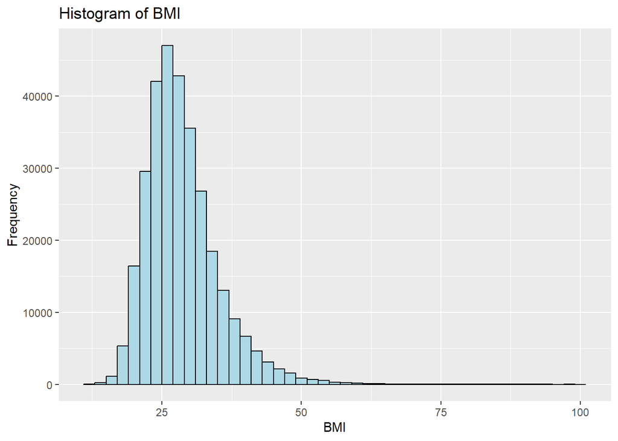

```r
ggplot(df_no_duplicates, aes(x = BMI)) +
  geom_histogram(binwidth = 2, color = "black", fill = "lightblue") +
  labs(title = "Histogram of BMI", x = "BMI", y = "Frequency")
```

#Creating Histogram for Height

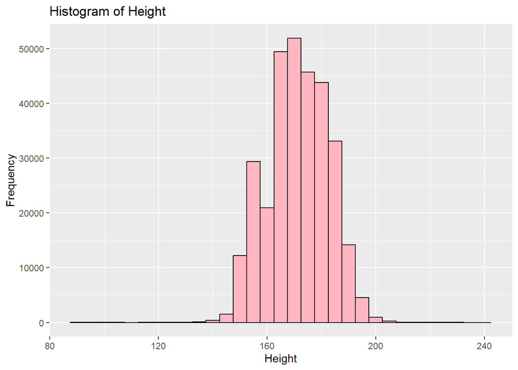

```r
ggplot(df_no_duplicates, aes(x = Height_.cm.)) +
  geom_histogram(binwidth = 5, color = "black", fill = "lightpink") +
  labs(title = "Histogram of Height", x = "Height", y = "Frequency")
```

#Creating Histogram for Weight

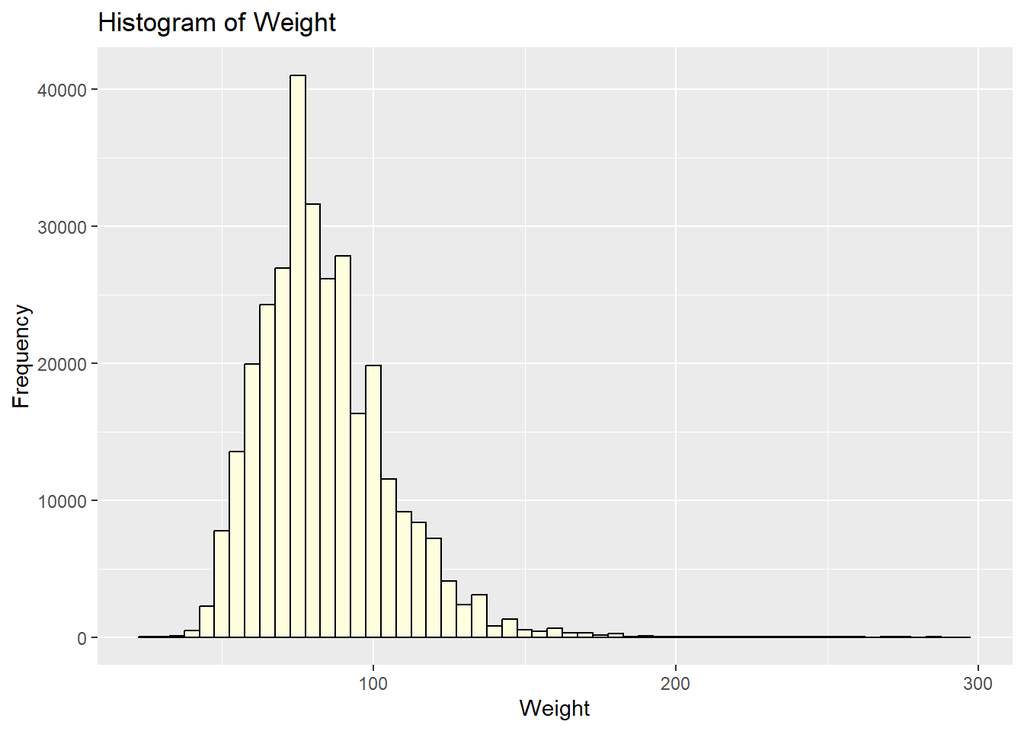

```r
ggplot(df_no_duplicates, aes(x = Weight_.kg.)) +
  geom_histogram(binwidth = 5, color = "black", fill = "lightyellow") +
  labs(title = "Histogram of Weight", x = "Weight", y = "Frequency")
```

#Creating Histogram for Alcohol Consumption

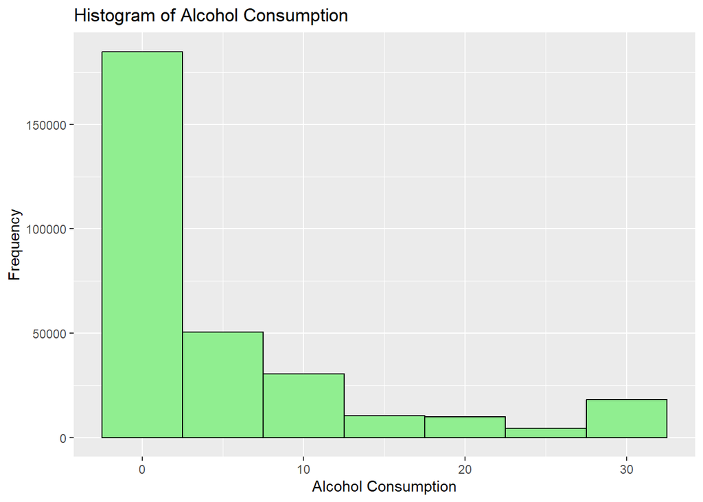

```r
ggplot(df_no_duplicates, aes(x = Alcohol_Consumption)) +
  geom_histogram(binwidth = 5, color = "black", fill = "lightgreen") +
  labs(title = "Histogram of Alcohol Consumption", x = "Alcohol Consumption", y = "Frequency")
```

#Creating Histogram for Fruit Consumption

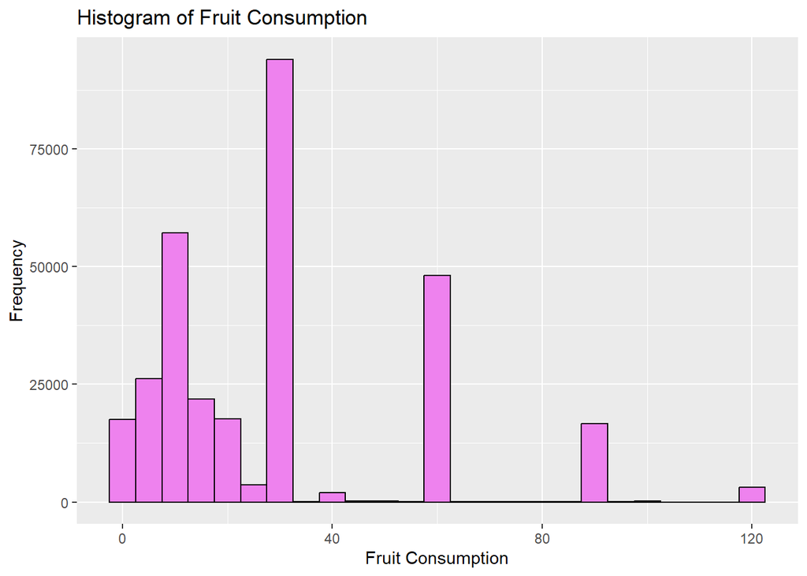

```r
ggplot(df_no_duplicates, aes(x = Fruit_Consumption)) +
  geom_histogram(binwidth = 5, color = "black", fill = "violet") +
  labs(title = "Histogram of Fruit Consumption", x = "Fruit Consumption", y = "Frequency")
```

#Creating Histogram for Green Vegetable Consumption

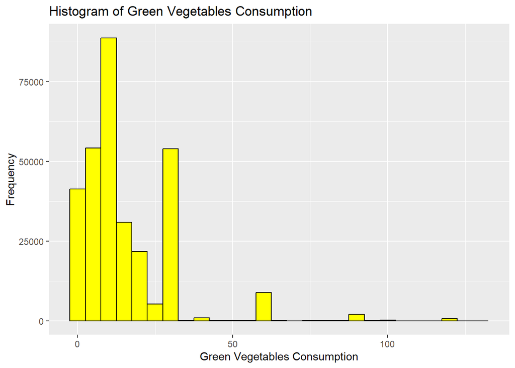

```r
ggplot(df_no_duplicates, aes(x = Green_Vegetables_Consumption)) +
  geom_histogram(binwidth = 5, color = "black", fill = "yellow") +
  labs(title = "Histogram of Green Vegetables Consumption", x = "Green Vegetables Consumption", y = "Frequency")
```

#Creating Histogram for Fried Potato Consumption

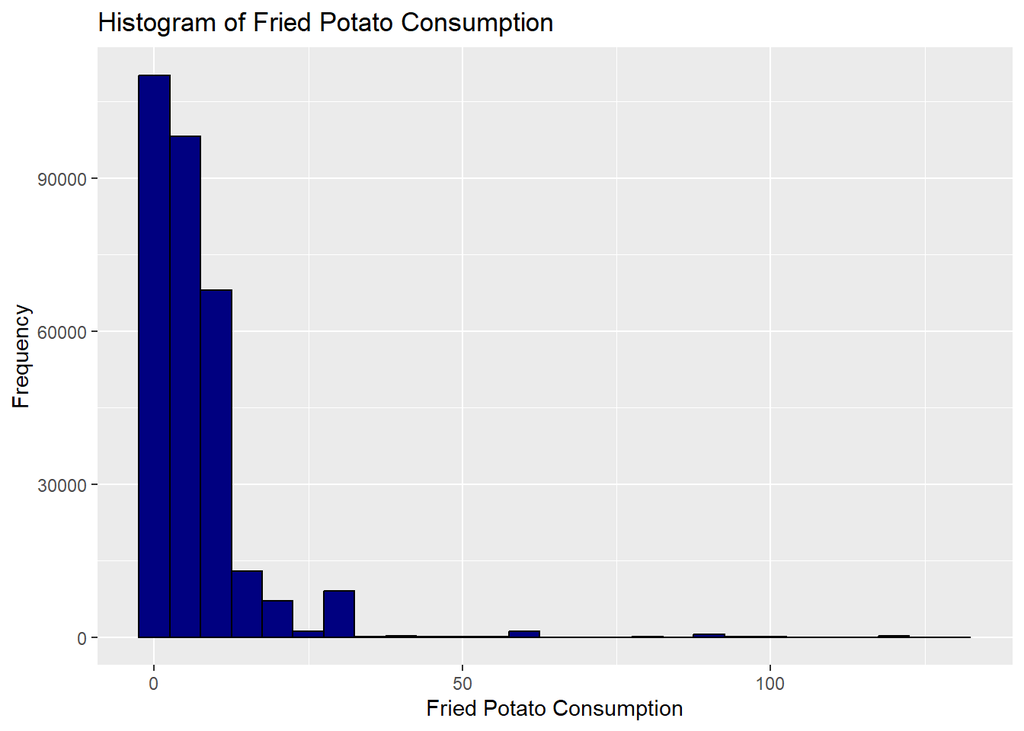

```r
ggplot(df_no_duplicates, aes(x = FriedPotato_Consumption)) +
  geom_histogram(binwidth = 5, color = "black", fill = "navy") +
  labs(title = "Histogram of Fried Potato Consumption", x = "Fried Potato Consumption", y = "Frequency")
```

# Creating Histograms for Categorical variables

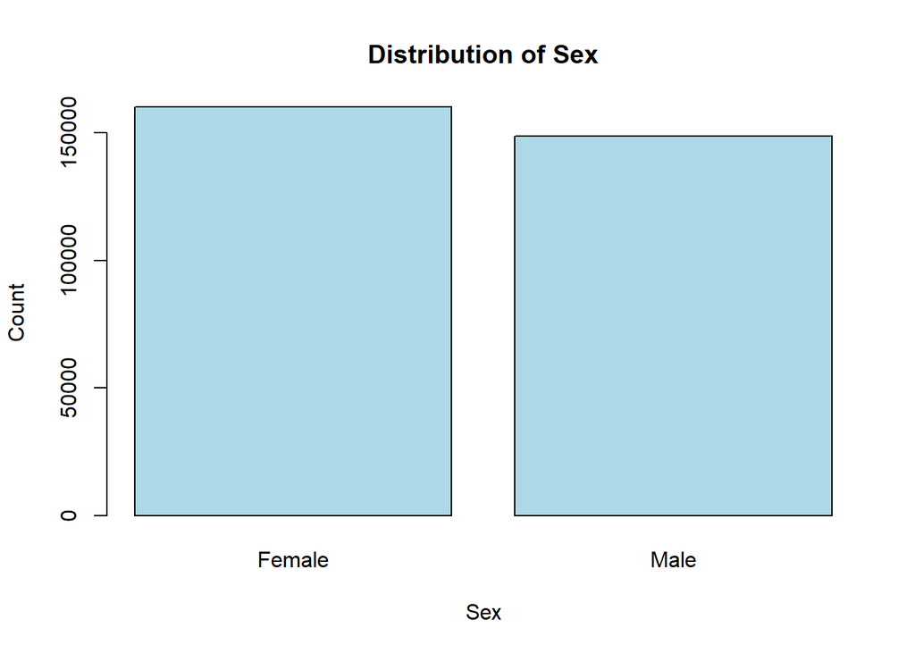

```r
barplot(sex_counts, col='lightblue', main='Distribution of Sex', xlab='Sex', ylab='Count')
```

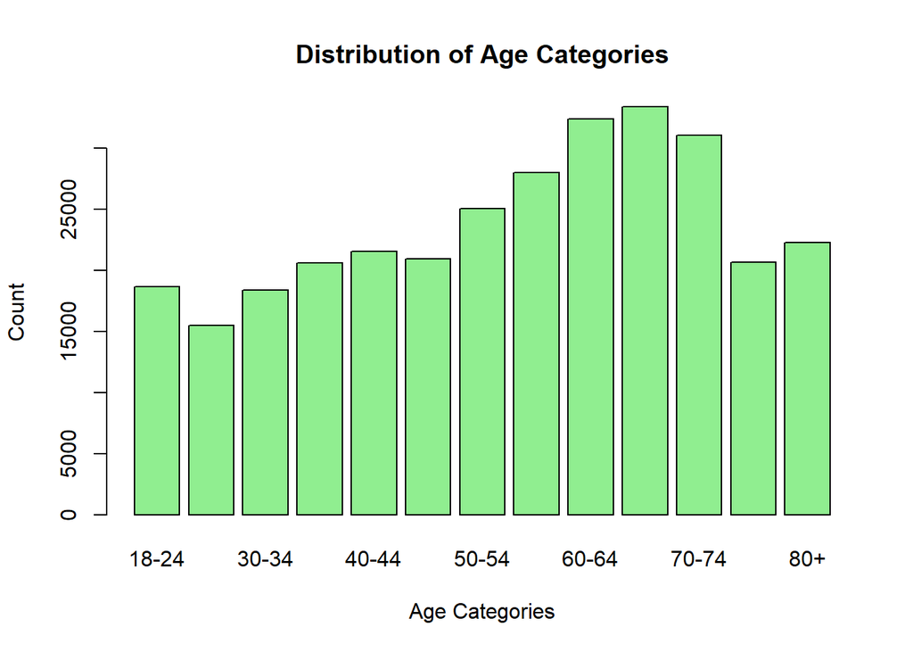

```r
barplot(age_counts, col='lightgreen', main='Distribution of Age Categories', xlab='Age Categories', ylab='Count')
```

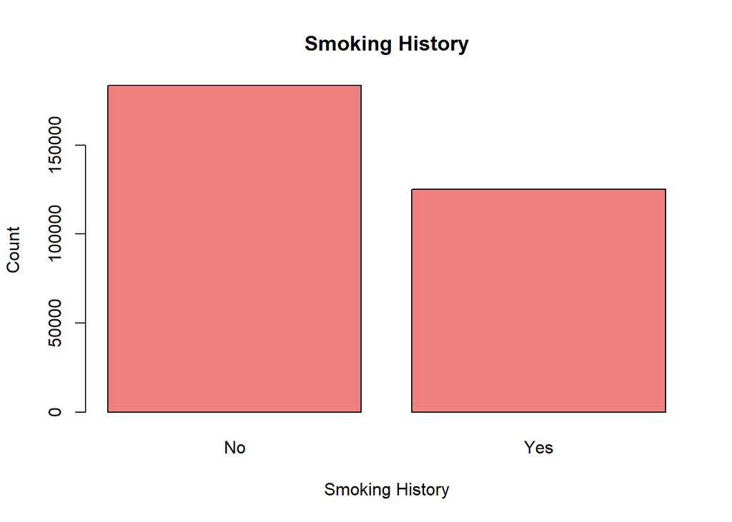

```r
barplot(smoking_counts, col='lightcoral', main='Smoking History', xlab='Smoking History', ylab='Count')
```

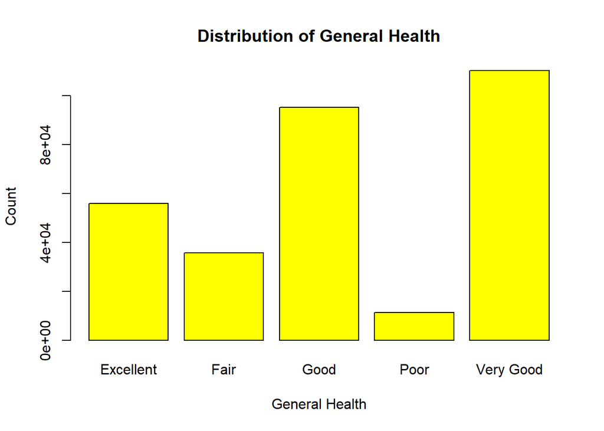

```r
barplot(General_Health_counts, col='yellow', main='Distribution of General Health', xlab='General Health', ylab='Count')
```

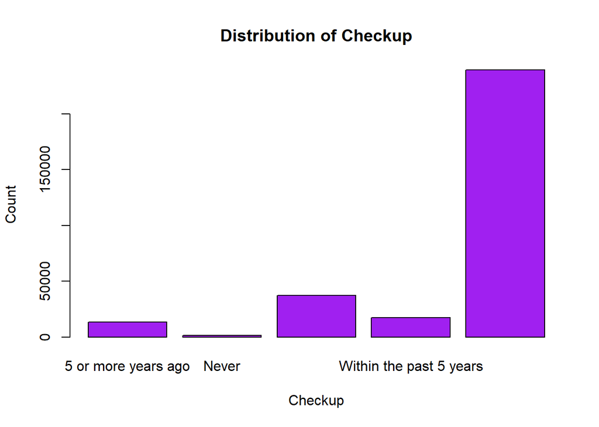

```r
barplot(Checkup_counts, col='purple', main='Distribution of Checkup', xlab='Checkup', ylab='Count')
```

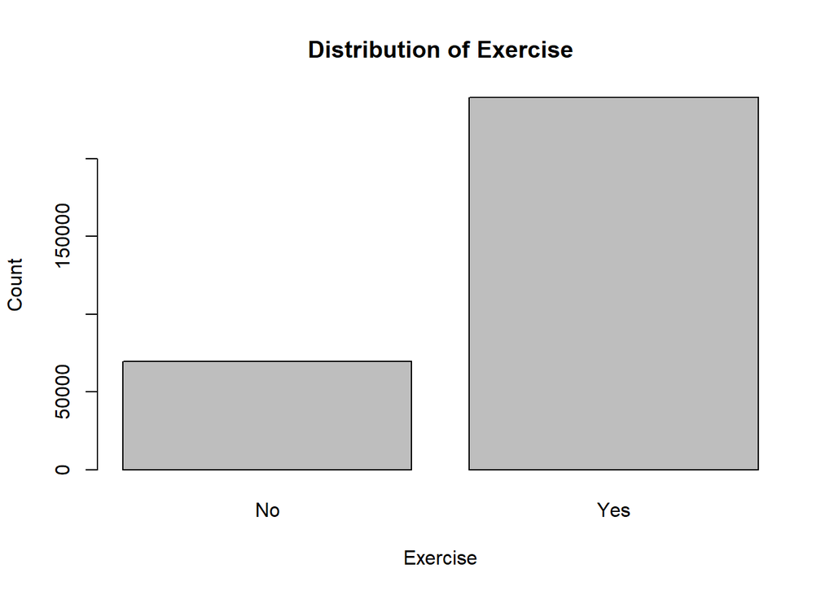

```r
barplot(Exercise_counts, col='grey', main='Distribution of Exercise', xlab='Exercise', ylab='Count')
```

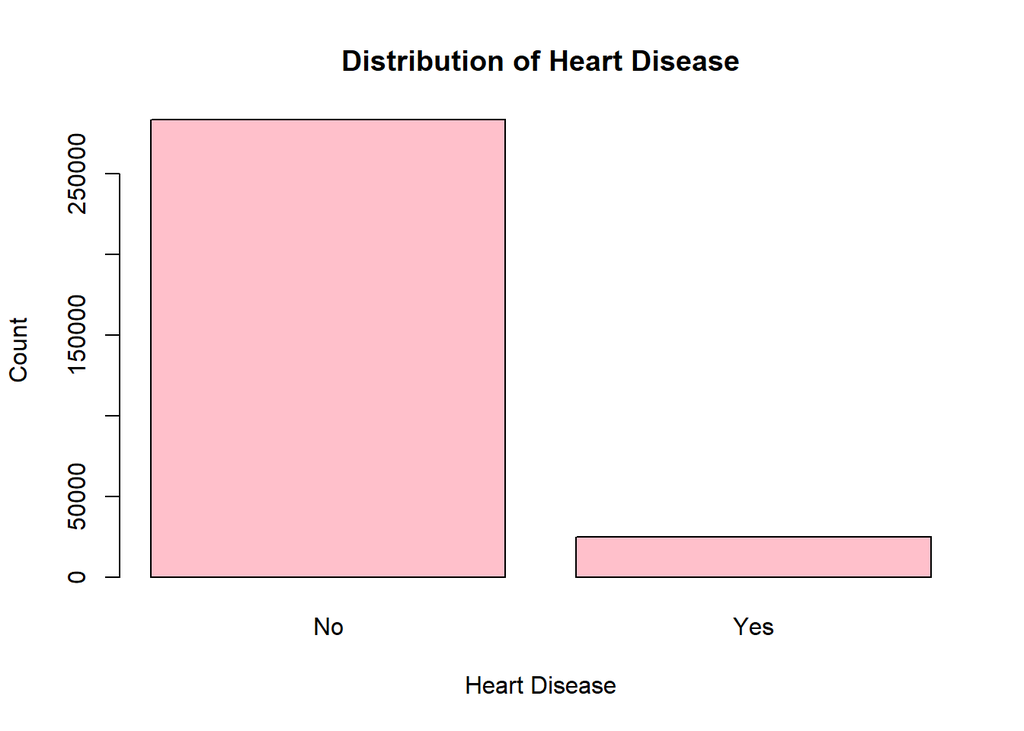

```r
barplot(Heart_Disease_counts, col='pink', main='Distribution of Heart Disease', xlab='Heart Disease', ylab='Count')
```

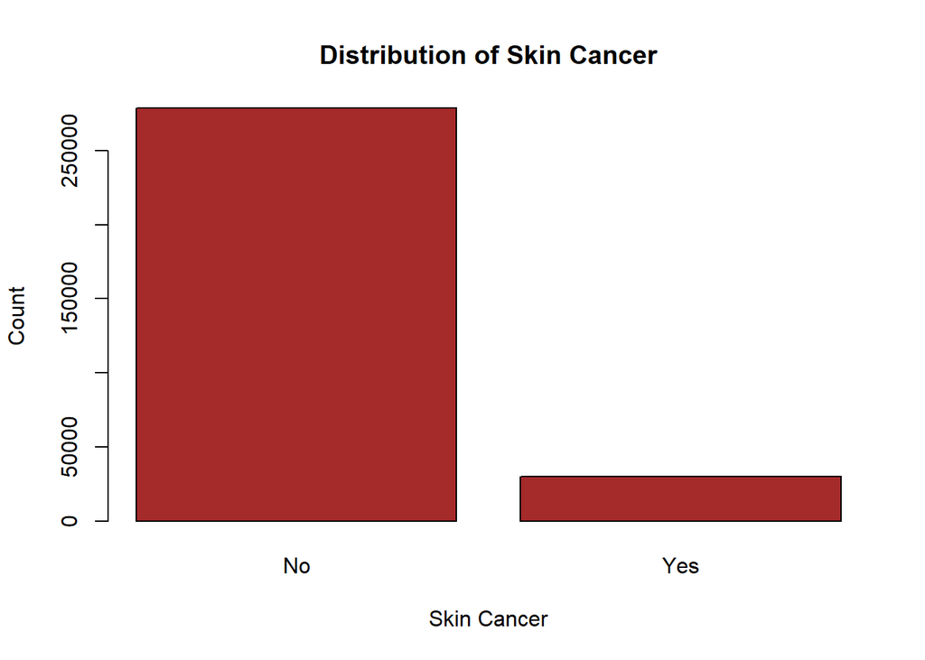

```r
barplot(Skin_Cancer_counts, col='brown', main='Distribution of Skin Cancer', xlab='Skin Cancer', ylab='Count')
```

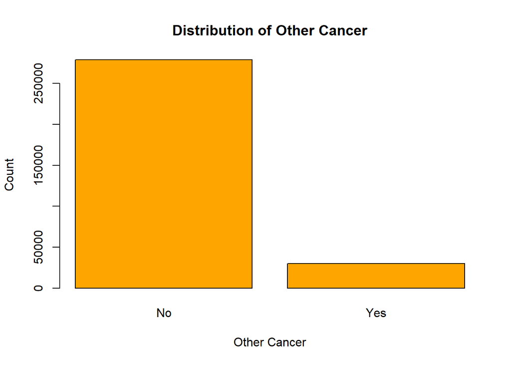

```r
barplot(Other_Cancer_counts, col='orange', main='Distribution of Other Cancer', xlab='Other Cancer', ylab='Count')
```

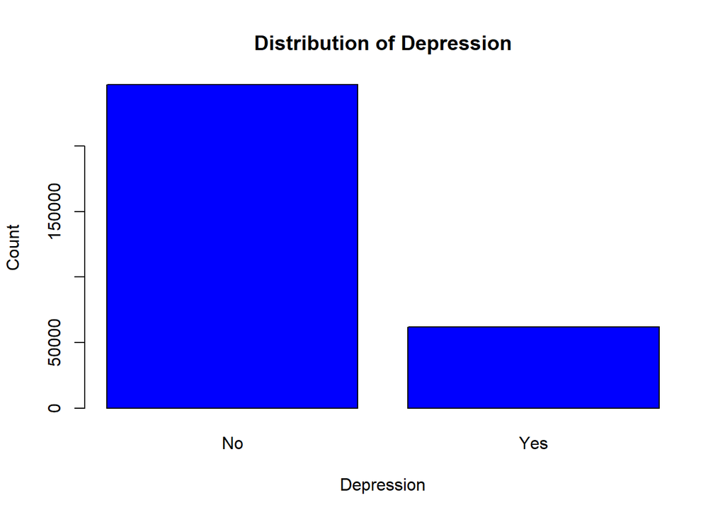

```r
barplot(Depression_counts, col='blue', main='Distribution of Depression', xlab='Depression', ylab='Count')
```

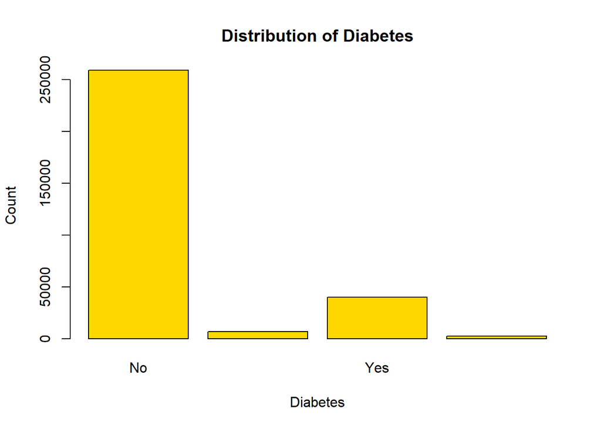

```r
barplot(Diabetes_counts, col='gold', main='Distribution of Diabetes', xlab='Diabetes', ylab='Count')
```

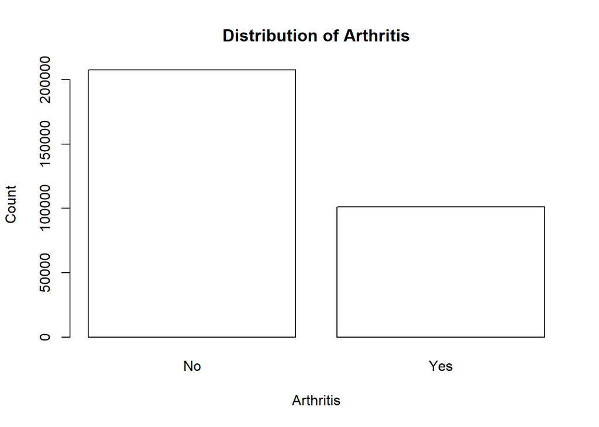

```r
barplot(Arthritis_counts, col='white', main='Distribution of Arthritis', xlab='Arthritis', ylab='Count')
```

#Encoding Categorical Variables ###Create a copy of the DataFrame to avoid modifying the original

```r
df_encoded <- df_no_duplicates
```

###Iterate through each character column and encode its values

```r
for (column in names(df_no_duplicates)[sapply(df_no_duplicates, is.character)]) {
  df_encoded[[column]] <- as.numeric(as.factor(df_encoded[[column]]))
}
head(df_encoded)
```

```
##   General_Health Checkup Exercise Heart_Disease Skin_Cancer Other_Cancer
## 1              4       3        1             1           1            1
## 2              5       5        1             2           1            1
## 3              5       5        2             1           1            1
## 4              4       5        2             2           1            1
## 5              3       5        1             1           1            1
## 6              3       5        1             1           1            1
##   Depression Diabetes Arthritis Sex Age_Category Height_.cm. Weight_.kg.   BMI
## 1          1        1         2   1           11         150       32.66 14.54
## 2          1        3         1   1           11         165       77.11 28.29
## 3          1        3         1   1            9         163       88.45 33.47
## 4          1        3         1   2           12         180       93.44 28.73
## 5          1        1         1   2           13         191       88.45 24.37
## 6          2        1         2   2            9         183      154.22 46.11
##   Smoking_History Alcohol_Consumption Fruit_Consumption
## 1               2                   0                30
## 2               1                   0                30
## 3               1                   4                12
## 4               1                   0                30
## 5               2                   0                 8
## 6               1                   0                12
##   Green_Vegetables_Consumption FriedPotato_Consumption
## 1                           16                      12
## 2                            0                       4
## 3                            3                      16
## 4                           30                       8
## 5                            4                       0
## 6                           12                      12
```

###Computing correlation matrix

```r
correlation_matrix <- cor(df_encoded)
correlation_matrix
```

```
##                              General_Health     Checkup     Exercise
## General_Health                 1.0000000000  0.02743140  0.036864116
## Checkup                        0.0274314026  1.00000000 -0.029803189
## Exercise                       0.0368641158 -0.02980319  1.000000000
## Heart_Disease                 -0.0206397213  0.08351317 -0.096321293
## Skin_Cancer                    0.0208635749  0.07931310 -0.003962542
## Other_Cancer                   0.0044555617  0.08677890 -0.054363195
## Depression                     0.0023131098  0.03567371 -0.084673136
## Diabetes                      -0.0251574656  0.12785793 -0.136589121
## Arthritis                      0.0140132812  0.15022463 -0.124784968
## Sex                           -0.0137334577 -0.10005776  0.059354908
## Age_Category                   0.0323775985  0.22311573 -0.122333667
## Height_.cm.                    0.0016343158 -0.08895078  0.091622336
## Weight_.kg.                    0.0148607872  0.01204328 -0.090120664
## BMI                            0.0139674101  0.06090295 -0.155731516
## Smoking_History                0.0043241593 -0.01006374 -0.093240646
## Alcohol_Consumption            0.0236733915 -0.04663120  0.095027914
## Fruit_Consumption             -0.0109565905  0.03929710  0.136781880
## Green_Vegetables_Consumption  -0.0215167685  0.03492467  0.124983337
## FriedPotato_Consumption       -0.0006818428 -0.05570618 -0.036904458
##                              Heart_Disease  Skin_Cancer Other_Cancer
## General_Health                -0.020639721  0.020863575  0.004455562
## Checkup                        0.083513171  0.079313098  0.086778897
## Exercise                      -0.096321293 -0.003962542 -0.054363195
## Heart_Disease                  1.000000000  0.090834786  0.092368897
## Skin_Cancer                    0.090834786  1.000000000  0.150780909
## Other_Cancer                   0.092368897  0.150780909  1.000000000
## Depression                     0.032493977 -0.013041082  0.015861114
## Diabetes                       0.166218386  0.032946623  0.063873236
## Arthritis                      0.153890793  0.136145665  0.129320216
## Sex                            0.072605767  0.009658134 -0.042060971
## Age_Category                   0.229027420  0.272075453  0.234463963
## Height_.cm.                    0.015782811  0.006798978 -0.043475600
## Weight_.kg.                    0.045854335 -0.028986190 -0.021169113
## BMI                            0.042641791 -0.037647408  0.001015064
## Smoking_History                0.107756804  0.032793210  0.053389737
## Alcohol_Consumption           -0.036614009  0.042734294 -0.008704319
## Fruit_Consumption             -0.020044952  0.024143027  0.007992321
## Green_Vegetables_Consumption  -0.024027409  0.012894149 -0.003215270
## FriedPotato_Consumption       -0.009248766 -0.038944606 -0.033325604
```

[output cut: 85 more lines]

```
## Skin_Cancer                            -0.0389446056
## Other_Cancer                           -0.0333256036
## Depression                              0.0181077426
## Diabetes                               -0.0042810650
## Arthritis                              -0.0509937803
## Sex                                     0.1300492729
## Age_Category                           -0.1427606301
## Height_.cm.                             0.1087903664
## Weight_.kg.                             0.0963268212
## BMI                                     0.0483428354
## Smoking_History                         0.0358242469
## Alcohol_Consumption                     0.0205028481
## Fruit_Consumption                      -0.0603022385
## Green_Vegetables_Consumption            0.0032094178
## FriedPotato_Consumption                 1.0000000000
```

###Extract upper triangular part of the correlation matrix (excluding diagonal)

```r
upper_triangle <- upper.tri(correlation_matrix)
```

###Extract correlation values from upper triangular part

```r
correlation_values <- correlation_matrix[upper_triangle]
```

###Find the indices of the highest correlations (excluding self-correlation)

```r
top_correlation_indices <- order(correlation_values, decreasing = TRUE)
```

###Get the variable pairs with the highest correlations

```r
top_correlation_pairs <- which(upper_triangle, arr.ind = TRUE)[top_correlation_indices, ]
```

###Print the top correlation pairs and their correlation values

```r
cat("Top correlation pairs:\n")
```

```
## Top correlation pairs:
```

```r
for (i in 1:min(10, nrow(top_correlation_pairs))) {
  var1 <- rownames(correlation_matrix)[top_correlation_pairs[i, 1]]
  var2 <- colnames(correlation_matrix)[top_correlation_pairs[i, 2]]
  correlation <- correlation_values[top_correlation_indices[i]]
  cat(var1, "-", var2, ": ", correlation, "\n")
}
```

```
## Weight_.kg. - BMI :  0.8597024
## Sex - Height_.cm. :  0.6981295
## Height_.cm. - Weight_.kg. :  0.4721749
## Arthritis - Age_Category :  0.3709959
## Sex - Weight_.kg. :  0.3539886
## Skin_Cancer - Age_Category :  0.2720755
## Fruit_Consumption - Green_Vegetables_Consumption :  0.2704255
## Other_Cancer - Age_Category :  0.234464
## Heart_Disease - Age_Category :  0.2290274
## Checkup - Age_Category :  0.2231157
```

###Extract correlations with the target variable (Heart_Disease)

```r
cor_with_Heart_Disease <- correlation_matrix["Heart_Disease", ]
cor_with_Heart_Disease
```

```
##               General_Health                      Checkup
##                 -0.020639721                  0.083513171
##                     Exercise                Heart_Disease
##                 -0.096321293                  1.000000000
##                  Skin_Cancer                 Other_Cancer
##                  0.090834786                  0.092368897
##                   Depression                     Diabetes
##                  0.032493977                  0.166218386
##                    Arthritis                          Sex
##                  0.153890793                  0.072605767
##                 Age_Category                  Height_.cm.
##                  0.229027420                  0.015782811
##                  Weight_.kg.                          BMI
##                  0.045854335                  0.042641791
##              Smoking_History          Alcohol_Consumption
##                  0.107756804                 -0.036614009
##            Fruit_Consumption Green_Vegetables_Consumption
##                 -0.020044952                 -0.024027409
##      FriedPotato_Consumption
##                 -0.009248766
```

####Sort correlations by absolute values in descending order

```r
sorted_cor <- sort(abs(cor_with_Heart_Disease), decreasing = TRUE)
sorted_cor
```

```
##                Heart_Disease                 Age_Category
##                  1.000000000                  0.229027420
##                     Diabetes                    Arthritis
##                  0.166218386                  0.153890793
##              Smoking_History                     Exercise
##                  0.107756804                  0.096321293
##                 Other_Cancer                  Skin_Cancer
##                  0.092368897                  0.090834786
##                      Checkup                          Sex
##                  0.083513171                  0.072605767
##                  Weight_.kg.                          BMI
##                  0.045854335                  0.042641791
##          Alcohol_Consumption                   Depression
##                  0.036614009                  0.032493977
## Green_Vegetables_Consumption               General_Health
##                  0.024027409                  0.020639721
##            Fruit_Consumption                  Height_.cm.
##                  0.020044952                  0.015782811
##      FriedPotato_Consumption
##                  0.009248766
```

####Select features with highest absolute correlations excluding target variable Heart_Disease

```r
selected_features <- names(sorted_cor)[-1]
selected_features
```

```
##  [1] "Age_Category"                 "Diabetes"
##  [3] "Arthritis"                    "Smoking_History"
##  [5] "Exercise"                     "Other_Cancer"
##  [7] "Skin_Cancer"                  "Checkup"
##  [9] "Sex"                          "Weight_.kg."
## [11] "BMI"                          "Alcohol_Consumption"
## [13] "Depression"                   "Green_Vegetables_Consumption"
## [15] "General_Health"               "Fruit_Consumption"
## [17] "Height_.cm."                  "FriedPotato_Consumption"
```

###Dropping highly correlated variables where vif>5 to enliminate multicolinarity

```r
set.seed(1031)
split = createDataPartition(y=df_encoded$Heart_Disease,p = 0.7,list = F,groups = 100)
train = df_encoded[split,]
test = df_encoded[-split,]
model <- lm(Heart_Disease ~., data = train)
vif_values <- vif(model)
high_vif_vars <- names(vif_values[vif_values > 5])
high_vif_vars
```

```
## [1] "Height_.cm." "Weight_.kg." "BMI"
```

###Use lasso feature selection method

```r
x = model.matrix(Heart_Disease~.-1,data=train)
y = train$Heart_Disease
set.seed(1031)
cv_lasso = cv.glmnet(x = x,
                     y = y,
                     alpha = 1,
                     type.measure = 'mse')
cv_lasso
```

```
##
## Call:  cv.glmnet(x = x, y = y, type.measure = "mse", alpha = 1)
##
## Measure: Mean-Squared Error
##
##       Lambda Index Measure        SE Nonzero
## min 0.000101    70 0.06739 0.0002697      18
## 1se 0.005048    28 0.06765 0.0002672      12
```

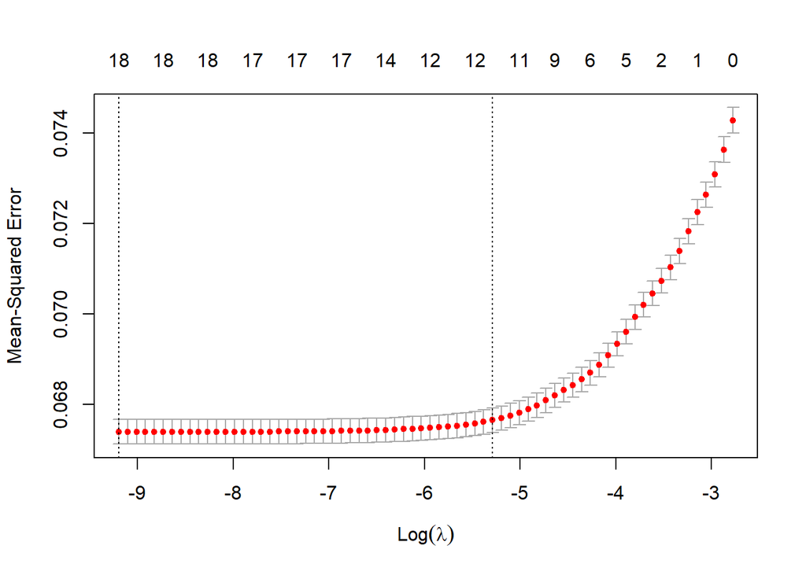

```r
plot(cv_lasso)
```

```r
coef(cv_lasso, s = cv_lasso$lambda.1se) |>
  round(6)
```

```
## 19 x 1 sparse Matrix of class "dgCMatrix"
##                                     s1
## (Intercept)                   0.786676
## General_Health               -0.000936
## Checkup                       0.003412
## Exercise                     -0.022804
## Skin_Cancer                   0.014019
## Other_Cancer                  0.014611
## Depression                    0.013195
## Diabetes                      0.036830
## Arthritis                     0.029301
## Sex                           0.041514
## Age_Category                  0.012245
## Height_.cm.                   .
## Weight_.kg.                   .
## BMI                           .
## Smoking_History               0.026167
## Alcohol_Consumption          -0.000541
## Fruit_Consumption             .
## Green_Vegetables_Consumption  .
## FriedPotato_Consumption       .
```

###Extracting most important features

```r
coefficients_lasso <- coef(cv_lasso, s = "lambda.1se")
important_features <- names(coefficients_lasso[coefficients_lasso[, "s1"] != 0, "s1"])
important_features
```

```
##  [1] "(Intercept)"         "General_Health"      "Checkup"
##  [4] "Exercise"            "Skin_Cancer"         "Other_Cancer"
##  [7] "Depression"          "Diabetes"            "Arthritis"
## [10] "Sex"                 "Age_Category"        "Smoking_History"
## [13] "Alcohol_Consumption"
```

##Writing Cleaned Dataset

```r
cleaned_df <- df_encoded[c("Heart_Disease", "General_Health", "Checkup", "Exercise", "Skin_Cancer", "Other_Cancer", "Depression", "Diabetes", "Arthritis", "Sex", "Age_Category", "Smoking_History","Alcohol_Consumption")]
head(cleaned_df)
```

```
##   Heart_Disease General_Health Checkup Exercise Skin_Cancer Other_Cancer
## 1             1              4       3        1           1            1
## 2             2              5       5        1           1            1
## 3             1              5       5        2           1            1
## 4             2              4       5        2           1            1
## 5             1              3       5        1           1            1
## 6             1              3       5        1           1            1
##   Depression Diabetes Arthritis Sex Age_Category Smoking_History
## 1          1        1         2   1           11               2
## 2          1        3         1   1           11               1
## 3          1        3         1   1            9               1
## 4          1        3         1   2           12               1
## 5          1        1         1   2           13               2
## 6          2        1         2   2            9               1
##   Alcohol_Consumption
## 1                   0
## 2                   0
## 3                   4
## 4                   0
## 5                   0
## 6                   0
```

```r
write.csv(cleaned_df, "C:/Users/rober/Desktop/APAN5205Project_CleanedDf.csv", row.names = FALSE)
```